# 497 final

*Name: Melih Can Kanmaz* / *No:2502169*

*Introduction:* *This analysis aims to forecast the ethereum prices. The dataset includes historical prices of the Ethereum from 2016 to 2024. The analysis includes test of various models to find the best model for the forecast. Starting from testing stationarity to findind best forecasts, this project consists all steps of a time series analysis of Ethereum price forecasting.*

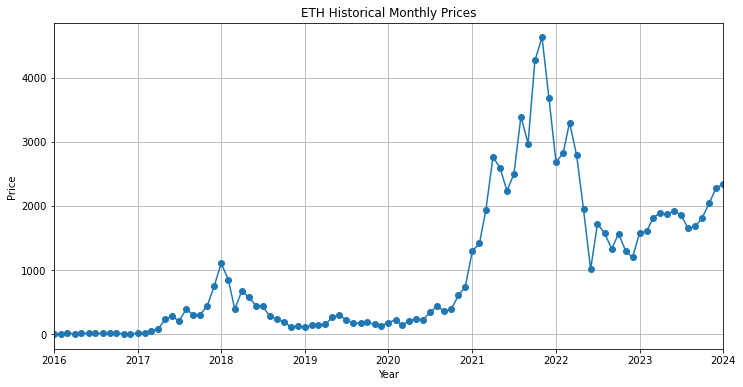

```python
# Part 1

#importing necessary libraries
import pandas as pd
import numpy as np
import matplotlib.pyplot as plt

df = pd.read_excel("ETH_2016_2024_monthly.xlsx")
df['Close'] = df['Close'].replace({',': ''}, regex=True).astype(float) # Formatting price for analysis
df['Date'] = pd.to_datetime(df['Date'], format='%m/%Y')  # Converting 'Date' column to datetime
df

# Time Series Plot
plt.figure(figsize=(12, 6))
plt.plot(df["Date"], df['Close'], marker='o')
plt.xlim([df["Date"].min(), df["Date"].max()])

plt.title('ETH Historical Monthly Prices')
plt.xlabel('Year')
plt.ylabel('Price')
plt.grid(True)

#plt.savefig('timeseries_plot.jpg', dpi=300, bbox_inches='tight')
```

*Interpretation:* *We have couple of trends in the graph, since it is financial data it is expected. Mean is not stationary and variance is not stable over time. We need to make it stationary before analyze.*

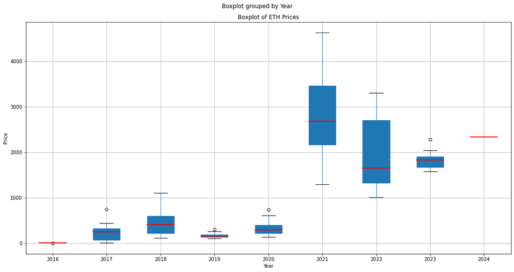

```python
# PART 1
df['Year'] = df['Date'].dt.year
df['Month'] = df['Date'].dt.month

#Boxplot for determining stationarity and seasonality
fig, ax = plt.subplots(figsize=(15, 8))
df.boxplot(column='Close', by='Year', patch_artist=True, ax=ax,
          medianprops=dict(color='red', linewidth=2))

ax.set_title('Boxplot of ETH Prices')
ax.set_xlabel('Year')
ax.set_ylabel('Price')

plt.tight_layout()

#plt.savefig('ts_boxplot.jpg', dpi=300, bbox_inches='tight')

plt.show()
```

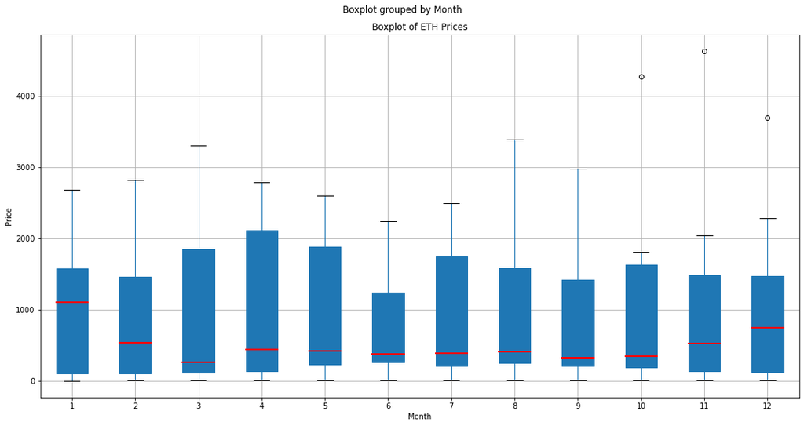

```python
fig, ax = plt.subplots(figsize=(15, 8))
df.boxplot(column='Close', by='Month', patch_artist=True, ax=ax,
          medianprops=dict(color='red', linewidth=2))

ax.set_title('Boxplot of ETH Prices')
ax.set_xlabel('Month')
ax.set_ylabel('Price')

plt.tight_layout()

#plt.savefig('ts_boxplot.jpg', dpi=300, bbox_inches='tight')

plt.show()
```

*Interpretation:* *Since the medians and means are vary the series does not look stationary. In addition, variances looks different ie data behave differently over time, which supports our previous decision as data is not stationary. From the graph it looks like there can be seasonality but first we need to check with HEGY or Canova Hansen test.*

```python
# PART 2

df = df.reset_index(drop=True) #Since the data is not indexed properly I needed to adjust it

#one time for every run
df["Date"] = pd.to_datetime(df["Date"])
df = df.set_index("Date")

#splitting data for train and test
df = df.sort_values('Date')

test = df.tail(12)

train = df.head(len(df) - 12)
print(df)
print(train)
print(test)
```

```
              Close  Year  Month
Date
2016-01-01     2.20  2016      1
2016-02-01     6.35  2016      2
2016-03-01    11.37  2016      3
2016-04-01     8.85  2016      4
2016-05-01    14.07  2016      5
...             ...   ...    ...
2023-09-01  1680.35  2023      9
2023-10-01  1814.72  2023     10
2023-11-01  2046.19  2023     11
2023-12-01  2282.96  2023     12
2024-01-01  2337.00  2024      1

[97 rows x 3 columns]
              Close  Year  Month
Date
2016-01-01     2.20  2016      1
2016-02-01     6.35  2016      2
2016-03-01    11.37  2016      3
2016-04-01     8.85  2016      4
2016-05-01    14.07  2016      5
...             ...   ...    ...
2022-09-01  1331.30  2022      9
2022-10-01  1566.34  2022     10
2022-11-01  1296.99  2022     11
2022-12-01  1199.52  2022     12
2023-01-01  1576.74  2023      1

[85 rows x 3 columns]
              Close  Year  Month
Date
2023-02-01  1605.47  2023      2
2023-03-01  1817.14  2023      3
2023-04-01  1892.35  2023      4
2023-05-01  1865.88  2023      5
2023-06-01  1927.83  2023      6
2023-07-01  1853.28  2023      7
2023-08-01  1647.42  2023      8
2023-09-01  1680.35  2023      9
2023-10-01  1814.72  2023     10
2023-11-01  2046.19  2023     11
2023-12-01  2282.96  2023     12
2024-01-01  2337.00  2024      1
```

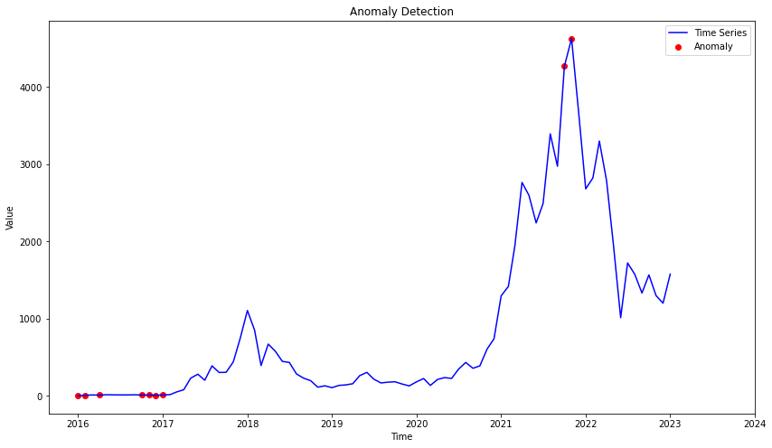

```python
# PART4
from sklearn.preprocessing import StandardScaler
from pyod.models.pca import PCA



#Scaling
scaler = StandardScaler()
scaled_data = scaler.fit_transform(train[['Close']])

# Anomaly Detection with PCA on pyOD library
model = PCA(contamination=0.1)
model.fit(scaled_data)

train['anomaly'] = model.predict(scaled_data)

plt.figure(figsize=(14, 8))
plt.plot(train.index, train['Close'], label='Time Series', color='blue')
plt.scatter(train.index[train['anomaly'] == 1], train['Close'][train['anomaly'] == 1], color='red', label='Anomaly')
plt.title('Anomaly Detection')
x_ticks = df["Close"].index[::12]
year_ticks = [pd.Timestamp(f"{year}-01-01") for year in x_ticks]
x_labels = [tick.strftime('%Y') for tick in x_ticks]
plt.xticks(ticks=x_ticks, labels=x_labels)
plt.xlabel('Time')
plt.ylabel('Value')
plt.legend()
plt.show()
```

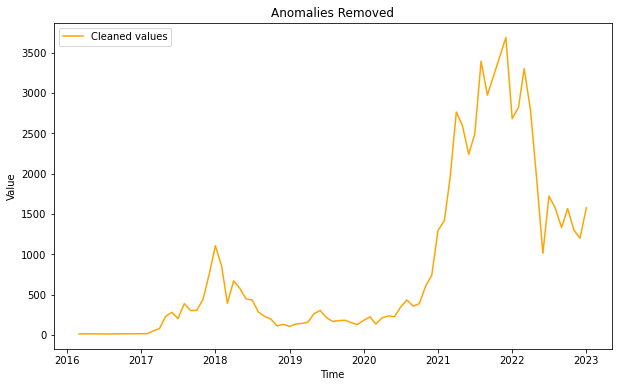

```python
# Removing anomalies from data
clean_train = train[train['anomaly'] == 0]

plt.figure(figsize=(10, 6))
plt.plot(clean_train.index, clean_train['Close'], label='Cleaned values', color='orange')
plt.title('Anomalies Removed')
plt.xlabel('Time')
plt.ylabel('Value')
plt.legend()
plt.show()
```

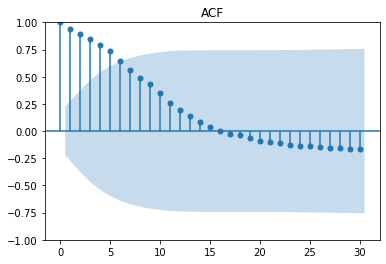

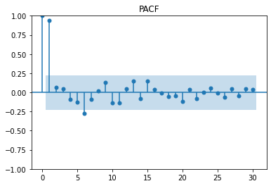

```python
# PART3
from scipy.stats import boxcox
from statsmodels.graphics.tsaplots import plot_acf, plot_pacf
from statsmodels.tsa.arima.model import ARIMA
from statsmodels.tools.eval_measures import aic, bic

# Plotting ACF  and PACF before fitting data and checking AIC BIC values for Box-Cox
plt.figure(figsize=(12, 6))
plot_acf(clean_train['Close'], lags=30)
plt.title('ACF')
plt.show()

plt.figure(figsize=(12, 6))
plot_pacf(clean_train['Close'], lags=30)
plt.title('PACF')
plt.show()
```

```
Box-Cox lambda is:0.15848431302479346
```

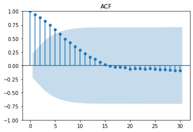

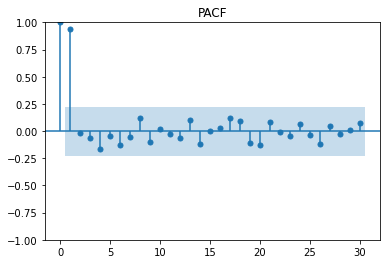

```python
# PART3
bc_data, bc_lambda = boxcox(clean_train['Close'])
clean_train['Transformed'] = bc_data

print(f"Box-Cox lambda is:{bc_lambda}")

# Plotting after Box-Cox transformation
plt.figure(figsize=(12, 6))
plot_acf(clean_train['Transformed'], lags=30)
plt.title('ACF')
plt.show()

plt.figure(figsize=(12, 6))
plot_pacf(clean_train['Transformed'], lags=30)
plt.title('PACF')
plt.show()
```

*Decision:* *According to the ACF plot there is an exponential decay. In PACF lag 1 is significant so ARMA(1,0) model can be suggested for evaluate AIC and BIC values*

```python
# PART3
raw_model = ARIMA(clean_train['Close'], order=(1,0,0))
fitted_raw = raw_model.fit()

# Box Cox values model fit
bc_model = ARIMA(clean_train["Transformed"], order=(1,0,0))
fitted_bc = bc_model.fit()

# AIC and BIC values
aic_raw = fitted_raw.aic
bic_raw = fitted_raw.bic
aic_bc = fitted_bc.aic
bic_bc = fitted_bc.bic

print(f"AIC for Raw Data: {aic_raw}")
print(f"BIC for Raw Data: {bic_raw}")
print(f"AIC for Box Cox Data: {aic_bc}")
print(f"BIC for Box Cox Data: {bic_bc}")

#if box cox values are significantly less than raw data making transformation
#I am not sure about threshold but values are already too different than threshold
if abs(aic_raw - aic_bc) > 10 and abs(bic_raw - bic_bc) > 10:
    clean_train['Close'] = bc_data
    test['Close'] = boxcox(test['Close'], lmbda=bc_lambda)
```

```
AIC for Raw Data: 1099.7977636852904
BIC for Raw Data: 1106.7899637061494
AIC for Box Cox Data: 207.17502063499816
BIC for Box Cox Data: 214.16722065585716
```

*Interpretation:* *Since Box-Cox transformation significantly decreased the AIC and BIC values we can say it is better to use it*

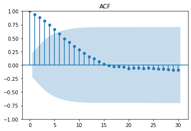

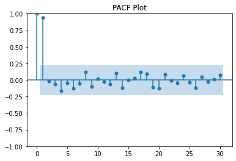

```python
#PART 5
series = clean_train['Close']


plt.figure(figsize=(14, 8))
plot_acf(series, lags=30)
plt.title('ACF')
plt.show()


plt.figure(figsize=(14, 8))
plot_pacf(series, lags=30)
plt.title('PACF Plot')
plt.show()
```

```python
#kpss test
from statsmodels.tsa.stattools import kpss
print("KPSS test for stationarity".center(50, "-"))
def kpss_test(series):
    statistic, p_value, lags, critical_values = kpss(series, regression='c', nlags="auto")
    print(f'KPSS value: {statistic}')
    print(f'p-value: {p_value}')
    print(f'Critical Values: {critical_values}')


kpss_test(series)
```

```
------------KPSS test for stationarity------------
KPSS value: 0.897753640617563
p-value: 0.01
Critical Values: {'10%': 0.347, '5%': 0.463, '2.5%': 0.574, '1%': 0.739}
```

*Decision:* *Since p value is less than 0.05 we reject H0 and conclude that series is not stationary*

```python
#ADF for stationarity
from statsmodels.tsa.stattools import adfuller
print("ADF test for stationarity".center(50, "-"))
def adf_test(series):
    result = adfuller(series)
    print(f'ADF value: {result[0]}')
    print(f'p-value: {result[1]}')
    print(f'Critical Values: {result[4]}')


adf_test(series)
```

```
------------ADF test for stationarity-------------
ADF value: -1.7221056883953265
p-value: 0.4197604533038781
Critical Values: {'1%': -3.520713130074074, '5%': -2.9009249540740742, '10%': -2.5877813777777776}
```

*Decision:* *Since p value is higher than 0.05 we fail reject H0 and conclude that series has unit root, therfore not stationary.*

```python
#ADF for trend
print("ADF test for trend".center(50, "-"))
result = adfuller(series, regression='ct')  # 'ct' is for trend

adf_statistic = result[0]
p_value = result[1]
critical_values = result[4]



print(f"ADF value: {adf_statistic}")
print(f"p-value: {p_value}")
print("Critical Values:")
for key, value in critical_values.items():
    print(f"   {key}: {value}")
```

```
----------------ADF test for trend----------------
ADF value: -1.7463622530406167
p-value: 0.7300294855111923
Critical Values:
   1%: -4.084849863703703
   5%: -3.4707426198518516
   10%: -3.1622754933333335
```

*Decision:* *Since series is not stationary we try to find the type of the trend it has, according to ADF we fail to reject H0, in conclusion series have stochastic trend*

```python
# KPSS for trend
print("KPSS test for trend".center(50, "-"))
kpss_result = kpss(series, regression='ct', nlags=12)  # 'ct' includes trend

kpss_statistic = kpss_result[0]
p_value = kpss_result[1]
critical_values = kpss_result[3]

print(f"KPSS value: {kpss_statistic}")
print(f"p-value: {p_value}")
print("Critical Values:")
for key, value in critical_values.items():
    print(f"   {key}: {value}")
```

```
---------------KPSS test for trend----------------
KPSS value: 0.0726249413781519
p-value: 0.1
Critical Values:
   10%: 0.119
   5%: 0.146
   2.5%: 0.176
   1%: 0.216
```

*Decision:* *KPSS test for trend shows that we fail to reject H0, conclude that series have deterministic trend. To be sure lets test with pp also.*

```python
#PP (PhillipsPerron) test
from arch.unitroot import PhillipsPerron

print("PP test for stationarity".center(50, "-"))
pp_test = PhillipsPerron(series)
print(pp_test.summary())
```

```
-------------PP test for stationarity-------------
     Phillips-Perron Test (Z-tau)
=====================================
Test Statistic                 -1.821
P-value                         0.370
Lags                               12
-------------------------------------

Trend: Constant
Critical Values: -3.52 (1%), -2.90 (5%), -2.59 (10%)
Null Hypothesis: The process contains a unit root.
Alternative Hypothesis: The process is weakly stationary.
```

*Decision:* *Since p value is higher than 0.05 we fail to reject H0 and conclude that series has unit root, not stationary*

```python
# PP test for trend
print("PP test for trend".center(50, "-"))
pp_test_trend = PhillipsPerron(series, trend='ct')
print(pp_test_trend.summary())
```

```
----------------PP test for trend-----------------
     Phillips-Perron Test (Z-tau)
=====================================
Test Statistic                 -2.157
P-value                         0.514
Lags                               12
-------------------------------------

Trend: Constant and Linear Time Trend
Critical Values: -4.08 (1%), -3.47 (5%), -3.16 (10%)
Null Hypothesis: The process contains a unit root.
Alternative Hypothesis: The process is weakly stationary.
```

*Decision:* *Since p value is higher than 0.05 we fail to reject H0 and series has stochastic trend*

```python
# Canova Hansen test
from pmdarima.arima import CHTest

ch = CHTest(m=12) #since the data is monthly we set m to 12
d_seasonal = ch.estimate_seasonal_differencing_term(series)
print(d_seasonal)
```

```
0
```

*Decision:* *Canova Hansen shows no seasonal roots in the series, so we can say series is not seasonal*

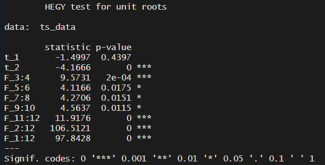

```python
# HEGY Test, I did this part in R since there is no library for HEGY in python, here is the ss of R output
from IPython.display import Image, display

image_path = "hegy test.png"

display(Image(filename=image_path))
```

*Decision:* *HEGY test shows there is unit root which shows series is not stationary and also there is no seasonal unit roots which means series does not have seasonality*

*PART6* *Since test results show that the series is not stationary and have stochastic trend we need to take regular differencing*

```python
# PART 6
clean_train['Close_diff'] = clean_train['Close'].diff()
clean_train.dropna(inplace=True)
diff_series = clean_train['Close_diff']
```

```python
from statsmodels.tsa.stattools import kpss

def kpss_test(series):
    statistic, p_value, lags, critical_values = kpss(series, regression='c', nlags="auto")
    print(f'KPSS Statistic: {statistic}')
    print(f'p-value: {p_value}')
    print(f'Critical Values: {critical_values}')

kpss_test(diff_series)
```

```
KPSS Statistic: 0.1471910641587757
p-value: 0.1
Critical Values: {'10%': 0.347, '5%': 0.463, '2.5%': 0.574, '1%': 0.739}
```

*Decision:* *Since p value is higher than 0.05 we fail to reject H0 and conclude that series is stationary*

```python
def adf_test(series):
    result = adfuller(series)
    print(f'ADF Statistic: {result[0]}')
    print(f'p-value: {result[1]}')
    print(f'Critical Values: {result[4]}')

# Apply ADF test
adf_test(diff_series)
```

```
ADF Statistic: -8.088167344347777
p-value: 1.4014518544256535e-12
Critical Values: {'1%': -3.5219803175527606, '5%': -2.9014701097664504, '10%': -2.58807215485756}
```

*Decision:* *Since p value is less than 0.05 we reject H0 and conclude that series has no unit root, therefore it is stationary*

```python
pp_test = PhillipsPerron(diff_series)

print(f"Test Statistic: {pp_test.stat}")
print(f"P-Value: {pp_test.pvalue}")
print("Critical Values:")
for key, value in pp_test.critical_values.items():
    print(f"   {key}: {value}")
```

```
Test Statistic: -8.28459881230778
P-Value: 4.4254799397893563e-13
Critical Values:
   1%: -3.5219803175527606
   5%: -2.9014701097664504
   10%: -2.58807215485756
```

*Decision:* *Since p value is less than 0.05 we reject H0 and conclude that series has no unit root, therefore it is stationary*

*Decision:* *Since after one regular differencing we reached a stationary series no need to take any more differencing*

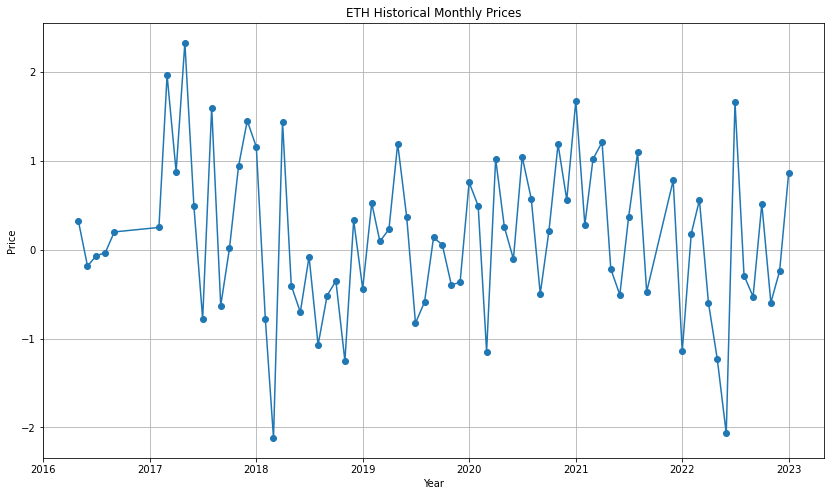

```python
# PART7
plt.figure(figsize=(14, 8))
plt.plot( diff_series, marker='o')

plt.title('ETH Historical Monthly Prices')
plt.xlabel('Year')
plt.ylabel('Price')
plt.grid(True)
plt.savefig('diff_ts_plot.jpg', dpi=300, bbox_inches='tight')
```

*Decision:* *Time series plot looks stationary.*

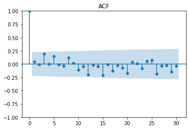

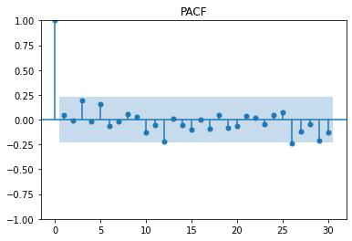

```python
# PART7
from scipy.stats import boxcox
from statsmodels.graphics.tsaplots import plot_acf, plot_pacf
from statsmodels.tsa.arima.model import ARIMA
from statsmodels.tools.eval_measures import aic, bic

# Plot ACF
plt.figure(figsize=(12, 6))
plot_acf(diff_series, lags=30)
plt.title('ACF')
plt.show()

# Plot PACF
plt.figure(figsize=(12, 6))
plot_pacf(diff_series, lags=30)
plt.title('PACF')
plt.show()
```

```python
diff_series.describe()
```

```
count    75.000000
mean      0.146566
std       0.886184
min      -2.119151
25%      -0.485171
50%       0.179588
75%       0.767449
max       2.327890
Name: Close_diff, dtype: float64
```

# PART8

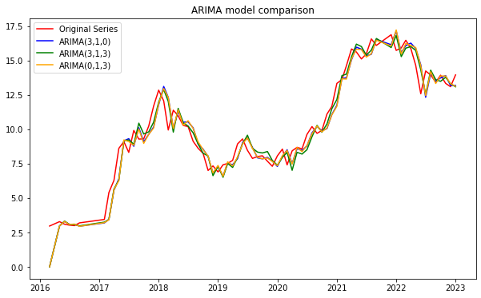

```
ARIMA(3,1,0) Summary:
                               SARIMAX Results
==============================================================================
Dep. Variable:                  Close   No. Observations:                   76
Model:                 ARIMA(3, 1, 0)   Log Likelihood                 -95.977
Date:                Sun, 05 Jan 2025   AIC                            199.954
Time:                        15:54:48   BIC                            209.224
Sample:                             0   HQIC                           203.655
                                 - 76
Covariance Type:                  opg
==============================================================================
                 coef    std err          z      P>|z|      [0.025      0.975]
------------------------------------------------------------------------------
ar.L1          0.0603      0.117      0.514      0.607      -0.169       0.290
ar.L2          0.0010      0.125      0.008      0.994      -0.243       0.245
ar.L3          0.2103      0.148      1.425      0.154      -0.079       0.499
sigma2         0.7555      0.125      6.051      0.000       0.511       1.000
===================================================================================
Ljung-Box (L1) (Q):                   0.01   Jarque-Bera (JB):                 0.87
Prob(Q):                              0.92   Prob(JB):                         0.65
Heteroskedasticity (H):               0.80   Skew:                            -0.13
Prob(H) (two-sided):                  0.59   Kurtosis:                         3.46
===================================================================================

Warnings:
[1] Covariance matrix calculated using the outer product of gradients (complex-step).

ARIMA(3,1,3) Summary:
                               SARIMAX Results
==============================================================================
Dep. Variable:                  Close   No. Observations:                   76
Model:                 ARIMA(3, 1, 3)   Log Likelihood                 -92.989
Date:                Sun, 05 Jan 2025   AIC                            199.978
Time:                        15:54:48   BIC                            216.200
Sample:                             0   HQIC                           206.455
                                 - 76
Covariance Type:                  opg
==============================================================================
                 coef    std err          z      P>|z|      [0.025      0.975]
------------------------------------------------------------------------------
```

[output cut: 28 more lines]

```
                 coef    std err          z      P>|z|      [0.025      0.975]
------------------------------------------------------------------------------
ma.L1          0.0769      0.108      0.714      0.475      -0.134       0.288
ma.L2         -0.0617      0.106     -0.584      0.559      -0.269       0.146
ma.L3          0.2406      0.128      1.876      0.061      -0.011       0.492
sigma2         0.7495      0.117      6.392      0.000       0.520       0.979
===================================================================================
Ljung-Box (L1) (Q):                   0.02   Jarque-Bera (JB):                 1.08
Prob(Q):                              0.88   Prob(JB):                         0.58
Heteroskedasticity (H):               0.80   Skew:                            -0.10
Prob(H) (two-sided):                  0.58   Kurtosis:                         3.55
===================================================================================

Warnings:
[1] Covariance matrix calculated using the outer product of gradients (complex-step).
```

```python
# PART9
# fitting ARIMA(3,1,0)
import statsmodels.api as sm

# fitting ARIMA(3,1,0)
arima310 = sm.tsa.ARIMA(series, order=(3, 1, 0))
fit310 = arima310.fit()

# fitting ARIMA(3,1,3)
arima313 = sm.tsa.ARIMA(series, order=(3, 1, 3))
fit313 = arima313.fit()

# fitting ARIMA(0,1,3)
arima013 = sm.tsa.ARIMA(series, order=(0, 1, 3))
fit013= arima013.fit()


# actual data vs fitted data
plt.figure(figsize=(10, 6))
plt.plot(series, label='Original Series', color='red')
plt.plot(fit310.fittedvalues, label='ARIMA(3,1,0)', color='blue')
plt.plot(fit313.fittedvalues, label='ARIMA(3,1,3)', color='green')
plt.plot(fit013.fittedvalues, label='ARIMA(0,1,3)', color='orange')
plt.legend()
plt.title('ARIMA model comparison')
plt.show()

# Model summaries
print("\nARIMA(3,1,0) Summary:")
print(fit310.summary())

print("\nARIMA(3,1,3) Summary:")
print(fit313.summary())

print("\nARIMA(0,1,3) Summary:")
print(fit013.summary())
```

*Decision* *According to the AIC and BIC values ARIMA(0,1,3) model looks better since it has less AIC and BIC. Also the significance of AR,MA values are a criteria when we choose the best model. In th first model AR value is not significant, the second model is significant in AR(3) value but not significant at MA(3) value.In the last model p value is 0.06 for MA(3), this is still not significant since it is >0.05 but comparing the other models this is the best we get.*

```
      lb_stat  lb_pvalue
20  14.903239   0.781917
```

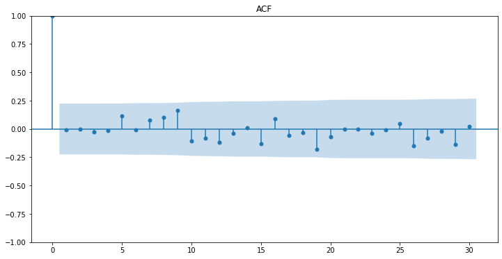

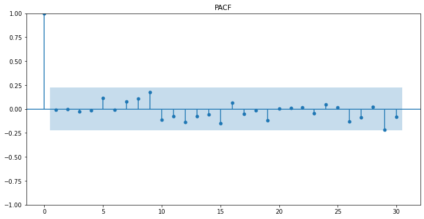

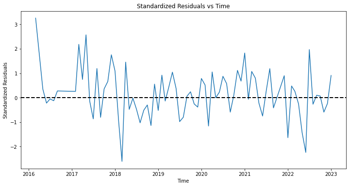

```python
#PART10 A
#Ljung-Box test as portmanteau test

from statsmodels.stats.diagnostic import acorr_ljungbox

residuals = fit013.resid

ljung_box_results = acorr_ljungbox(residuals, lags=[20], return_df=True)

print(ljung_box_results)

plt.figure(figsize=(12, 6))
plot_acf(residuals, lags=30, ax=plt.gca())
plt.title("ACF")
plt.show()

plt.figure(figsize=(12, 6))
plot_pacf(residuals, lags=30, ax=plt.gca())
plt.title("PACF")
plt.show()


standardized_residuals = residuals / np.std(residuals)

plt.figure(figsize=(12, 6))
plt.plot(standardized_residuals)
plt.axhline(0, color='black', linestyle='--', linewidth=2)
plt.title("Standardized Residuals vs Time")
plt.xlabel("Time")
plt.ylabel("Standardized Residuals")
plt.show()
```

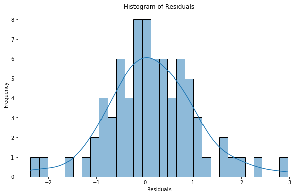

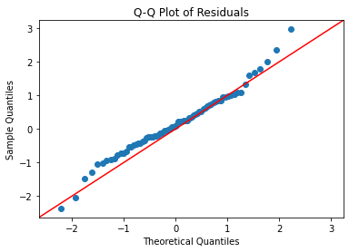

```
Shapiro-Wilk Test Statistic: 0.9847105741500854
Shapiro-Wilk Test p-value: 0.4945319592952728
Jarque-Bera Test Statistic: 3.3795292549467226
Jarque-Bera Test p-value: 0.18456295993117844
Skewness: 0.19687366796252087
Kurtosis: 3.955082614317709
```

```python
# PART10 B
from statsmodels.stats.diagnostic import normal_ad
from statsmodels.stats.stattools import jarque_bera
import seaborn as sns
from scipy import stats

# Histogram of residuals
plt.figure(figsize=(10, 6))
sns.histplot(residuals, kde=True, bins=30)
plt.title("Histogram of Residuals")
plt.xlabel("Residuals")
plt.ylabel("Frequency")
plt.show()

# Q-Q plot for normality
sm.qqplot(residuals, line='45')
plt.title("Q-Q Plot of Residuals")
plt.show()

# Shapiro-Wilk Test for normality
shapiro_stat, shapiro_p_value = stats.shapiro(residuals)
print(f"Shapiro-Wilk Test Statistic: {shapiro_stat}")
print(f"Shapiro-Wilk Test p-value: {shapiro_p_value}")

# Jarque-Bera Test for normality
jb_stat, jb_p_value, jb_skew, jb_kurt = jarque_bera(residuals)

print(f"Jarque-Bera Test Statistic: {jb_stat}")
print(f"Jarque-Bera Test p-value: {jb_p_value}")
print(f"Skewness: {jb_skew}")
print(f"Kurtosis: {jb_kurt}")
```

*Decision:* *Since both p values of Shapiro-Wilk and Jarque-Bera test is higher than 0.05 we fail to reject H0 and conclude that residuals are normally distributed.*

```python
# PART10 C
from statsmodels.stats.diagnostic import acorr_breusch_godfrey

bg_test = acorr_breusch_godfrey(fit013, nlags=12)
bg_stat, bg_p_value, _, _ = bg_test

print(f"Breusch-Godfrey Test Statistic: {bg_stat}")
print(f"p-value: {bg_p_value}")
```

```
Breusch-Godfrey Test Statistic: 8.556214537017414
p-value: 0.740295052275115
```

*Decision:* *p value is higher than 0.05 so fail to reject H0 and conclude that there is no significant autocorrelation in residuals.*

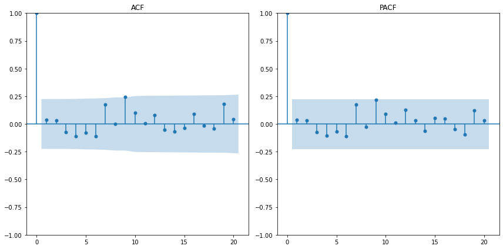

```
ARCH Test Results:
Test Statistic: 4.8094
p-value: 0.9035
Lags (Number of Obs - Model df): 0.4322798467906018
Critical Values: 0.9243896558657123
```

```python
from statsmodels.stats.diagnostic import het_arch

squared_residuals = residuals**2

plt.figure(figsize=(12, 6))
plt.subplot(1, 2, 1)
plot_acf(squared_residuals, ax=plt.gca(), lags=20, title="ACF")
plt.subplot(1, 2, 2)
plot_pacf(squared_residuals, ax=plt.gca(), lags=20, title="PACF")
plt.tight_layout()
plt.show()

arch_test_result = het_arch(residuals)

print("ARCH Test Results:")
print(f"Test Statistic: {arch_test_result[0]:.4f}")
print(f"p-value: {arch_test_result[1]:.4f}")
print(f"Lags (Number of Obs - Model df): {arch_test_result[2]}")
print(f"Critical Values: {arch_test_result[3]}")
```

*Decision:* *p value is higher than 0.05 so fail to reject H0 and conclude that there is no significant heteroscedasticity.*

*PART 11*

```python
#PART11 A
from statsmodels.tsa.api import SimpleExpSmoothing
from statsmodels.tsa.holtwinters import Holt
from statsmodels.tsa.holtwinters import ExponentialSmoothing
from sklearn.neural_network import MLPRegressor
from sklearn.metrics import mean_absolute_percentage_error

forecasts = {}
forecasts['ARIMA'] =  fit013.forecast(steps=12)
```

```
Forecast Accuracy Measures:
SES: MAPE = 3.97%, MAE = 0.59, RMSE = 0.69
Holt: MAPE = 3.27%, MAE = 0.47, RMSE = 0.59
Holt-Winter: MAPE = 6.25%, MAE = 0.90, RMSE = 1.06

Best Model: Holt with MAPE = 3.27%
```

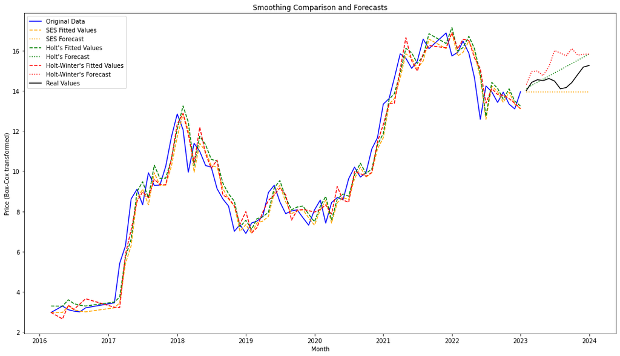

```python
#PART 11 B

from sklearn.metrics import mean_absolute_percentage_error, mean_absolute_error, mean_squared_error

# Generate a proper time index for the series
series_index = series.index

# Simple Exponential Smoothing
model = SimpleExpSmoothing(series)
model_single_fit = model.fit()
forecast_single = model_single_fit.forecast(12)

# Holt's Exponential Smoothing
model_double = Holt(series)
model_double_fitted = model_double.fit()
holts_forecast = model_double_fitted.forecast(12)

# Holt-Winters Exponential Smoothing
model_triple = ExponentialSmoothing(
    series, seasonal_periods=12, trend="add", seasonal="add"
)
model_triple_fit = model_triple.fit()
forecast_triple = model_triple_fit.forecast(12)

# Define forecast indices
forecast_index = np.arange(len(train), len(train) + 12)

forecasts = {
    "SES": forecast_single,
    "Holt": holts_forecast,
    "Holt-Winter": forecast_triple
}

# Accuracy metrics
# Ensure both test and forecast are numeric and aligned
accuracy_measures = {}
for model, forecast in forecasts.items():
    # Ensure alignment
    forecast = pd.Series(forecast).reset_index(drop=True)
    test_aligned = test["Close"].reset_index(drop=True)

    # Calculate metrics
    mape = mean_absolute_percentage_error(test_aligned, forecast)
    mae = mean_absolute_error(test_aligned, forecast)
    rmse = np.sqrt(mean_squared_error(test_aligned, forecast))
    accuracy_measures[model] = {"MAPE": mape, "MAE": mae, "RMSE": rmse}

# Display accuracy measures
print("Forecast Accuracy Measures:")
for model, metrics in accuracy_measures.items():
    print(f"{model}: MAPE = {metrics['MAPE']:.2%}, MAE = {metrics['MAE']:.2f}, RMSE = {metrics['RMSE']:.2f}")

# Determine the best model
best_model = min(accuracy_measures, key=lambda x: accuracy_measures[x]['MAPE'])
print(f"\nBest Model: {best_model} with MAPE = {accuracy_measures[best_model]['MAPE']:.2%}")

# Plotting forecasts
forecast_index = test.index

plt.figure(figsize=(18, 10))

# Original series
plt.plot(series.index, series, label="Original Data", color="blue")

# Fitted and forecasted values
plt.plot(series.index, model_single_fit.fittedvalues, label="SES Fitted Values", linestyle="--", color="orange")
plt.plot(forecast_index, forecast_single, label="SES Forecast", linestyle=":", color="orange")

plt.plot(series.index, model_double_fitted.fittedvalues, label="Holt's Fitted Values", linestyle="--", color="green")
plt.plot(forecast_index, holts_forecast, label="Holt's Forecast", linestyle=":", color="green")

plt.plot(series.index, model_triple_fit.fittedvalues, label="Holt-Winter's Fitted Values", linestyle="--", color="red")
plt.plot(forecast_index, forecast_triple, label="Holt-Winter's Forecast", linestyle=":", color="red")

plt.plot(forecast_index, test["Close"], label="Real Values", color="black")

# Annotations
plt.xlabel("Month")
plt.ylabel("Price (Box-Cox transformed)")
plt.title("Smoothing Comparison and Forecasts")
plt.legend()
plt.show()
```

*Decision* *According to the values Holt's is the best exponential smoothing method*

[figure not shown]

[output not shown]

[output not shown]

```python
#PART 11 C
#I tried but couldn't run the prophet model, the error I get in the output
from prophet.plot import add_changepoints_to_plot
from prophet import Prophet
import pandas as pd
import matplotlib.pyplot as plt

image_path = "prophet_error.png"

display(Image(filename=image_path))

prophet_data = train.reset_index().rename(columns={'Date': 'ds', 'Close': 'y'})
m = Prophet()
m.fit(prophet_data)

future = m.make_future_dataframe(periods=12 * 5,
                                 freq='M')

forecast = m.predict(future)
forecast[['ds', 'yhat', 'yhat_lower',
          'yhat_upper', 'trend',
          'trend_lower', 'trend_upper']].tail()
```

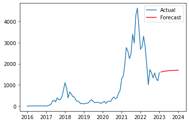

```python
#PART11 D
from tbats import TBATS
tbats_series = prophet_data.set_index('ds')['y'] #from the prophet model
tbats_model = TBATS(seasonal_periods=[12])
tbats_fitted_model = tbats_model.fit(tbats_series)
tbats_forecast = tbats_fitted_model.forecast(steps=12)
plt.plot(tbats_series.index, tbats_series.values, label='Actual')
plt.plot(pd.date_range(tbats_series.index[-1], periods=12, freq='M'), tbats_forecast, label='Forecast', color='red')
plt.legend()
plt.show()
```

```python
#PART11 E
from sklearn.neural_network import MLPRegressor

df['Close'] = df['Close'].replace(',', '', regex=True).astype(float)

# Recreate train-test split
train_data = df.iloc[:-12]['Close']
test_data = df.iloc[-12:]['Close']

mlp_model = MLPRegressor(hidden_layer_sizes=(100,), max_iter=1000, random_state=0)
X_train = np.arange(len(train_data)).reshape(-1, 1)
y_train = train_data.values
mlp_model.fit(X_train, y_train)
X_test = np.arange(len(train_data), len(train_data) + 12).reshape(-1, 1)
forecast_nn = mlp_model.predict(X_test)

# Recompute accuracy metrics
accuracy = mean_absolute_percentage_error(test_data, forecast_nn)

print(f"Accuracy:{accuracy}")
```

```
Accuracy:0.1330805685839735
```

```python
#PART 12

original_fitted = np.power(fit013.fittedvalues * bc_lambda + 1, 1 / bc_lambda)

# Obtain forecast and prediction intervals
forecast_arima = fit013.get_forecast(steps=12)

# Extract forecasted mean and confidence intervals
forecast_mean = forecast_arima.predicted_mean
confidence_intervals = forecast_arima.conf_int()

# Extract lower and upper bounds
lower_limits = confidence_intervals.iloc[:, 0]
upper_limits = confidence_intervals.iloc[:, 1]

# Back-transform the forecast
original_forecast = np.power(forecast_mean * bc_lambda + 1, 1 / bc_lambda)
original_lw = np.power(lower_limits * bc_lambda + 1, 1 / bc_lambda)
original_up = np.power(upper_limits * bc_lambda + 1, 1 / bc_lambda)

# Display results
print("Back-Transformed Forecast:\n", original_forecast)
print("Back-Transformed Lower Bound:\n", original_lw)
print("Back-Transformed Upper Bound:\n", original_up)
```

```
Back-Transformed Forecast:
 76    1551.344943
77    1501.783990
78    1598.195963
79    1598.195963
80    1598.195963
81    1598.195963
82    1598.195963
83    1598.195963
84    1598.195963
85    1598.195963
86    1598.195963
87    1598.195963
Name: predicted_mean, dtype: float64
Back-Transformed Lower Bound:
```

[output cut: 27 more lines]

```python
#PART 13
from sklearn.metrics import mean_absolute_error, mean_squared_error

# Holt's Exponential Smoothing with original data
model_double = Holt(train["Close"])
model_double_fit = model_double.fit()
holts_forecast = model_double_fit.forecast(12)

# Forecasts from different models (replace these with actual forecasts from your models)
forecasts = {
    "ARIMA": original_forecast,
    "TBATS":tbats_forecast,
    "Holt": holts_forecast,
    "Neural Network": forecast_nn
}

# Initialize a dictionary to store accuracy metrics
accuracy_measures = {}

# Loop through each model and compute metrics
test["Close"] = np.power(test["Close"] * bc_lambda + 1, 1 / bc_lambda)
print(test)
for model, forecast in forecasts.items():
    forecast = pd.Series(forecast).reset_index(drop=True)
    test_aligned = test["Close"].reset_index(drop=True)
    print(model)
    print(forecast)

    mape = mean_absolute_percentage_error(test["Close"], forecast)
    mae = mean_absolute_error(test["Close"], forecast)
    rmse = np.sqrt(mean_squared_error(test["Close"], forecast))
    accuracy_measures[model] = {"MAPE": mape, "MAE": mae, "RMSE": rmse}

# Display accuracy measures for each model
print("Forecast Accuracy Measures:")
for model, metrics in accuracy_measures.items():
    print(f"{model}: MAPE = {metrics['MAPE']:.2%}, MAE = {metrics['MAE']:.2f}, RMSE = {metrics['RMSE']:.2f}")

# Determine the best model based on MAPE
best_model = min(accuracy_measures, key=lambda x: accuracy_measures[x]['MAPE'])
print(f"\nBest Model: {best_model} with MAPE = {accuracy_measures[best_model]['MAPE']:.2%}")
```

```
              Close  Year  Month
Date
2023-02-01  1605.47  2023      2
2023-03-01  1817.14  2023      3
2023-04-01  1892.35  2023      4
2023-05-01  1865.88  2023      5
2023-06-01  1927.83  2023      6
2023-07-01  1853.28  2023      7
2023-08-01  1647.42  2023      8
2023-09-01  1680.35  2023      9
2023-10-01  1814.72  2023     10
2023-11-01  2046.19  2023     11
2023-12-01  2282.96  2023     12
2024-01-01  2337.00  2024      1
ARIMA
0     1551.344943
1     1501.783990
2     1598.195963
3     1598.195963
4     1598.195963
5     1598.195963
6     1598.195963
7     1598.195963
8     1598.195963
9     1598.195963
10    1598.195963
11    1598.195963
Name: predicted_mean, dtype: float64
TBATS
0     1608.286497
1     1626.940496
2     1642.000605
3     1654.136940
4     1663.902811
5     1671.752027
6     1678.054857
7     1683.112178
8     1687.167693
9     1690.418299
10    1693.022752
```

[output cut: 22 more lines]

```
5     2093.026038
6     2116.139277
7     2139.252516
8     2162.365754
9     2185.478993
10    2208.592232
11    2231.705470
dtype: float64
Forecast Accuracy Measures:
ARIMA: MAPE = 15.40%, MAE = 311.29, RMSE = 377.02
TBATS: MAPE = 11.54%, MAE = 237.43, RMSE = 309.59
Holt: MAPE = 14.53%, MAE = 294.91, RMSE = 361.77
Neural Network: MAPE = 13.31%, MAE = 236.98, RMSE = 271.85

Best Model: TBATS with MAPE = 11.54%
```

*Decision* *According to the evaluation metrics TBATS model is better fit for this model.After that the 2nd choice can use Neural Networks.*

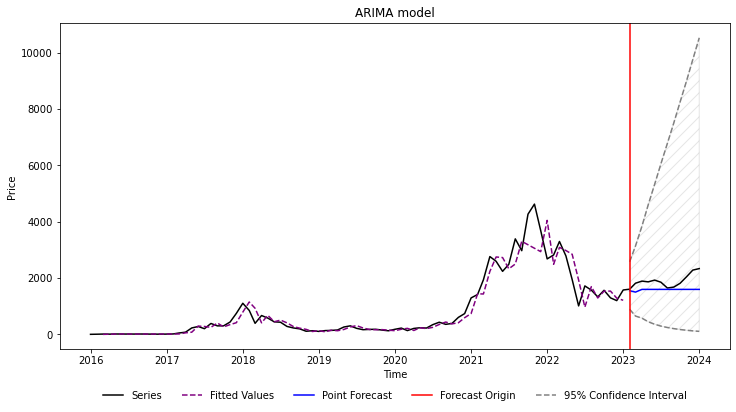

```python
# PART 14
#ARIMA

forecast_intervals = forecast_arima.conf_int()
forecast_origin = len(df) - 12

plt.figure(figsize=(12, 6))
plt.plot(df["Close"].index, df["Close"], label="Series", color="black")
plt.plot(series.index, original_fitted, label="Fitted Values", linestyle="--", color="purple")
plt.plot(test.index, original_forecast, label="Point Forecast", color="blue")

# Dashed gray lines for prediction intervals
plt.plot(test.index, original_lw, linestyle="--", color="gray")
plt.plot(test.index, original_up, linestyle="--", color="gray")

# Filling between the dashed lines with hatched pattern
plt.fill_between(
    test.index,
    original_lw,
    original_up,
    color="white",  # Set fill color to white
    alpha=0.2,
    hatch='//',
    edgecolor='gray'
)

plt.axvline(x=df["Close"].index[forecast_origin], color="red", linestyle="-", label="Forecast Origin")

plt.title("ARIMA model")
plt.xlabel("Time")
plt.ylabel("Price")

plt.plot([], [], linestyle="--", color="gray", label="95% Confidence Interval")


#the following lines are for one run
#df["Date"] = pd.to_datetime(df["Date"])
#df = df.set_index("Date")

x_ticks = df["Close"].index[::12]
year_ticks = [pd.Timestamp(f"{year}-01-01") for year in x_ticks]
x_labels = [tick.strftime('%Y') for tick in x_ticks]

plt.xticks(ticks=x_ticks, labels=x_labels)

# Moving the legend below the plot
plt.legend(loc='upper center', bbox_to_anchor=(0.5, -0.1), ncol=5, frameon=False)

plt.show()
```

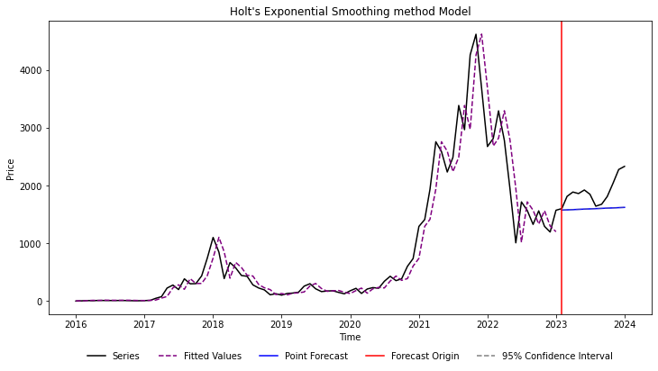

```python
# PART 14
#Exponential Smoothing method as Holt's

forecast_origin = len(df) - 12

plt.figure(figsize=(12, 6))
plt.plot(df["Close"].index, df["Close"], label="Series", color="black")
plt.plot(train.index, model_double_fit.fittedvalues, label="Fitted Values", linestyle="--", color="purple")
plt.plot(test.index, holts_forecast, label="Point Forecast", color="blue")

stderr = np.std(residuals)
holts_forecast_df = pd.Series(holts_forecast, index=forecast_index)
lower_bound = holts_forecast_df - 1.96 * stderr
upper_bound = holts_forecast_df + 1.96 * stderr

#Dashed gray lines for prediction intervals
plt.plot(test.index, lower_bound, linestyle="--", color="gray",alpha=0.2)
plt.plot(test.index, upper_bound, linestyle="--", color="gray",alpha=0.2)

# Filling between the dashed lines with hatched pattern
plt.fill_between(
    test.index,
    lower_bound,
    upper_bound,
    color="white",
    alpha=0.2,
    hatch='//',
    edgecolor='gray'
)

plt.axvline(x=df["Close"].index[forecast_origin], color="red", linestyle="-", label="Forecast Origin")

plt.title("Holt's Exponential Smoothing method Model")
plt.xlabel("Time")
plt.ylabel("Price")

plt.plot([], [], linestyle="--", color="gray", label="95% Confidence Interval")

x_ticks = df["Close"].index[::12]
year_ticks = [pd.Timestamp(f"{year}-01-01") for year in x_ticks]
x_labels = [tick.strftime('%Y') for tick in x_ticks]

plt.xticks(ticks=x_ticks, labels=x_labels)

# Moving the legend below the plot
plt.legend(loc='upper center', bbox_to_anchor=(0.5, -0.1), ncol=5, frameon=False)

plt.show()
```

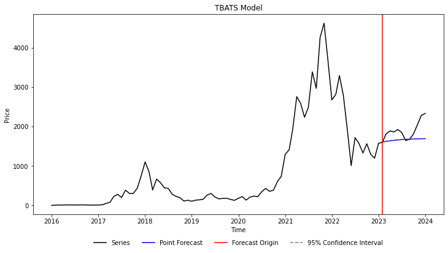

```python
# PART 14
#TBATS
plt.figure(figsize=(12, 6))
plt.plot(df["Close"].index, df["Close"], label="Series", color="black")
plt.plot(test.index, tbats_forecast, label="Point Forecast", color="blue")

stderr = np.std(residuals)
tbats_forecast_df = pd.Series(tbats_forecast, index=forecast_index)
lower_bound = tbats_forecast_df - 1.96 * stderr
upper_bound = tbats_forecast_df + 1.96 * stderr

#Dashed gray lines for prediction intervals
plt.plot(test.index, lower_bound, linestyle="--", color="gray",alpha=0.2)
plt.plot(test.index, upper_bound, linestyle="--", color="gray",alpha=0.2)

# Filling between the dashed lines with hatched pattern
plt.fill_between(
    test.index,
    lower_bound,
    upper_bound,
    color="white",
    alpha=0.2,
    hatch='//',
    edgecolor='gray'
)

plt.axvline(x=df["Close"].index[forecast_origin], color="red", linestyle="-", label="Forecast Origin")

plt.title("TBATS Model")
plt.xlabel("Time")
plt.ylabel("Price")

plt.plot([], [], linestyle="--", color="gray", label="95% Confidence Interval")

x_ticks = df["Close"].index[::12]
year_ticks = [pd.Timestamp(f"{year}-01-01") for year in x_ticks]
x_labels = [tick.strftime('%Y') for tick in x_ticks]

plt.xticks(ticks=x_ticks, labels=x_labels)

# Moving the legend below the plot
plt.legend(loc='upper center', bbox_to_anchor=(0.5, -0.1), ncol=5, frameon=False)

plt.show()
```

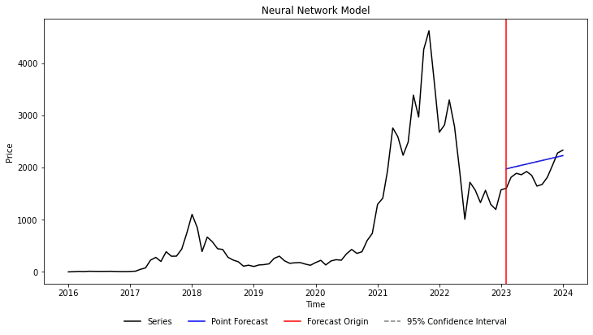

```python
# PART 14
#Neural Network

plt.figure(figsize=(12, 6))
plt.plot(df["Close"].index, df["Close"], label="Series", color="black")
plt.plot(test.index, forecast_nn, label="Point Forecast", color="blue")

stderr = np.std(residuals)
forecast_nn_df = pd.Series(forecast_nn, index=forecast_index)
lower_bound = forecast_nn_df - 1.96 * stderr
upper_bound = forecast_nn_df + 1.96 * stderr

#Dashed gray lines for prediction intervals
plt.plot(test.index, lower_bound, linestyle="--", color="gray",alpha=0.2)
plt.plot(test.index, upper_bound, linestyle="--", color="gray",alpha=0.2)

# Filling between the dashed lines with hatched pattern
plt.fill_between(
    test.index,
    lower_bound,
    upper_bound,
    color="white",
    alpha=0.2,
    hatch='//',
    edgecolor='gray'
)

plt.axvline(x=df["Close"].index[forecast_origin], color="red", linestyle="-", label="Forecast Origin")

plt.title("Neural Network Model")
plt.xlabel("Time")
plt.ylabel("Price")

plt.plot([], [], linestyle="--", color="gray", label="95% Confidence Interval")

x_ticks = df["Close"].index[::12]
year_ticks = [pd.Timestamp(f"{year}-01-01") for year in x_ticks]
x_labels = [tick.strftime('%Y') for tick in x_ticks]

plt.xticks(ticks=x_ticks, labels=x_labels)

# Moving the legend below the plot
plt.legend(loc='upper center', bbox_to_anchor=(0.5, -0.1), ncol=5, frameon=False)

plt.show()
```

*Conclusion*